# Introducción a la estadística

Escuela Técnica Superior de Ingeniería de Barcelona Este  
Universitat Politècnica de Catalunya (UPC)

Capítulo 9

# Objetivo

- Hipótesis
- Prueba de hipótesis

# Estimación

A partir de los datos, podemos estimar

- la media $\mu$ por $\bar{x}$
- el intervalo de confianza aleatorio por $CI=(l,u)=(\bar{x}-z_{\alpha/2} \frac{\sigma}{\sqrt{n}}, \bar{x}+z_{\alpha/2} \frac{\sigma}{\sqrt{n}})$

Cuando creemos que la variable aleatoria sigue una distribución normal y conocemos la varianza.

# Estimación

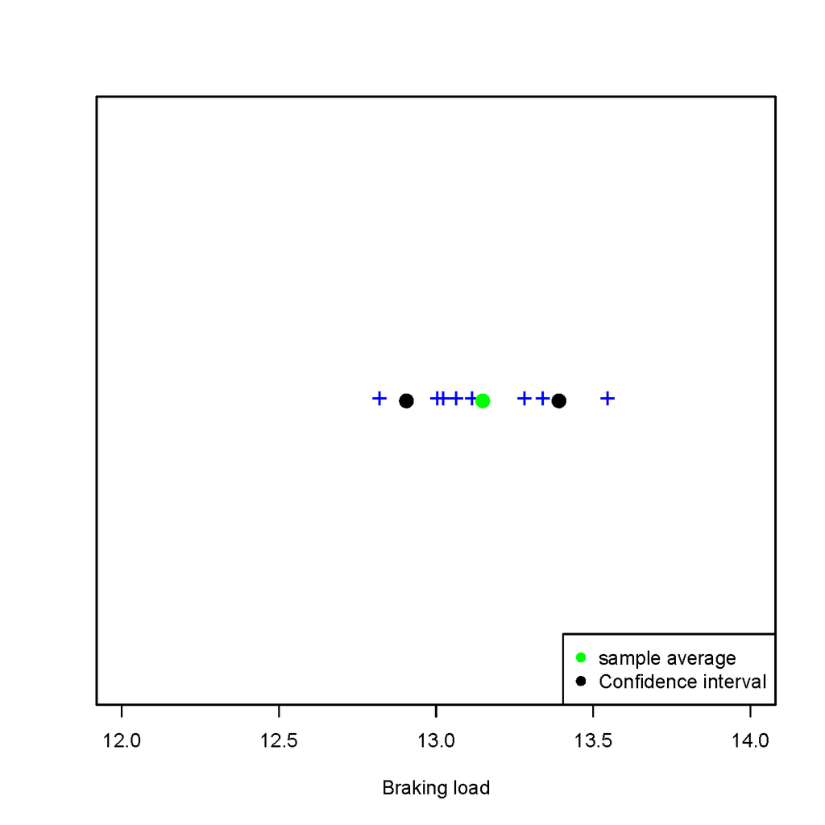

# Estimación

Sin embargo, no sabemos (**nunca**) dónde están la verdadera distribución de la muestra y de la población.

Todas estas distribuciones muestrales podrían producir la media observada.

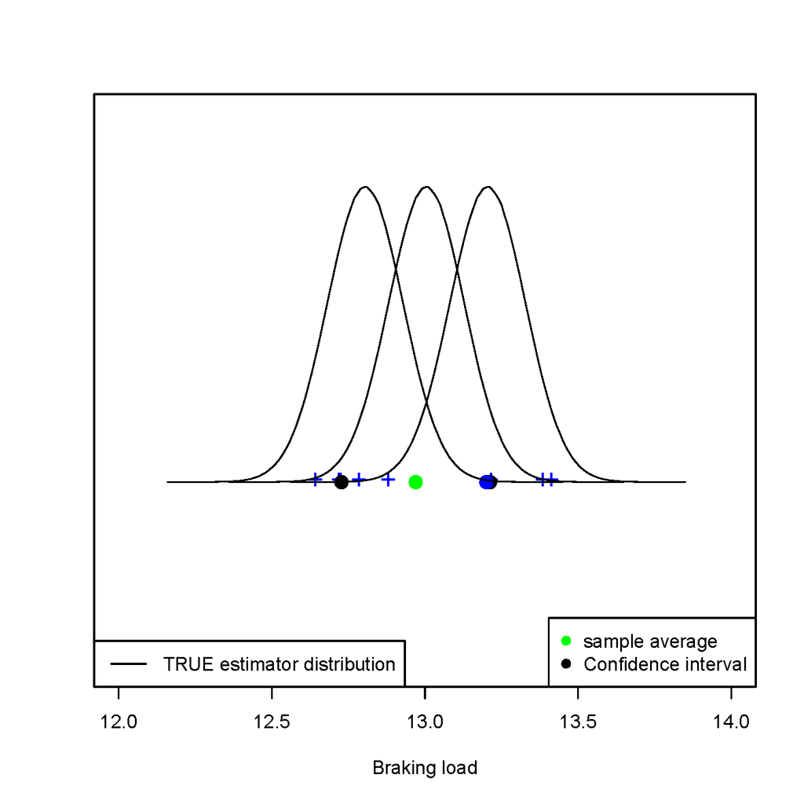

# Hipótesis

Siempre que tomamos medidas tenemos una ‘’idea’’ de lo que queremos hacer con ellas

- Las mediciones proporcionan **evidencia** para esa idea.
- Podemos formular esa idea en términos de nuestra **suposición** de la distribución verdadera.
- No conocemos la distribución verdadera pero nos interesa saber qué tipo de observación obtendríamos si hicieramos suposiciones al respecto.

# Hipótesis

Si estamos interesados en cargas de rotura, ¿podemos **suponer** que los cables se rompen en promedio a las 12 Toneladas, o las 14 Toneladas?

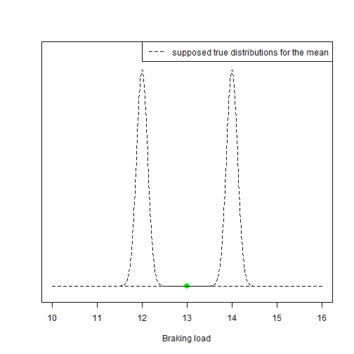

# Hipótesis

Ejemplos:

- Los fabricantes de neumáticos quieren saber si la vida media de los neumáticos que producen es de al menos 20.000 km.
- Los fabricantes de fertilizantes quieren probar si su nuevo producto tiene un efecto real en el crecimiento de las plantas.
- Las empresas farmacéuticas necesitan saber si la quimioterapia puede curar al 90% de los pacientes con cáncer.

Estas preguntas se pueden traducir en proposociones sobre las distribuciones de probabilidad.

# Hipótesis

- Los fabricantes de neumáticos quieren saber si la vida media de los neumáticos que producen es de al menos 20.000 km.

Suponiendo que la vida útil de los neumáticos sigue una distribución de probabilidad poblacional, nos interesa encontrar si la media de la distribución es de al menos 20 000 km.

Esto se puede hacer en dos proposiciones dicotómicas.

- La vida media de los neumáticos es **menor** de 20.000 km
- La vida media de los neumáticos es **mayor** que 20.000 km

# Hipótesis

o siendo $\mu$ la media de la distribución de la población

- $H_0: \mu \leq 20,000km$
- $H_1: \mu > 20,000km$

# Hipótesis

**Definición**

En estadística, una proposición (conjetura) sobre la distribución de una variable aleatoria se llama **hipótesis**.

La hipótesis suele estar redactada en dos afirmaciones dicotómicas

- La hipótesis **nula**: $H_0$ cuando la conjetura es falsa
- La hipótesis **alternativa**: $H_1$ cuando la conjetura es verdadera

# Hipótesis nula

Entonces, ¿cuáles son las hipótesis nula y alternativa para estas situaciones?

- Los fabricantes de neumáticos quieren saber si la vida media de los neumáticos que producen es de al menos 20.000 km.
- Los fabricantes de fertilizantes quieren probar si su nuevo producto tiene un efecto real en el crecimiento de las plantas.
- Las empresas farmacéuticas deben saber si la quimioterapia puede curar al 90% de los pacientes con cáncer.

# Hipótesis nula

- Los fabricantes de fertilizantes quieren probar si su nuevo producto tiene un efecto real en el crecimiento de las plantas.

Siendo $\mu_0$ el crecimiento medio de las plantas **sin** fertilizante (conocido/esperado) y el crecimiento medio de las plantas con el fertilizante $\mu$ (desconocido)

- $H_0:\mu \leq \mu_0$ (El fertilizante no hace nada: efecto nulo)
- $H_1:\mu > \mu_0$ (El fertilizante tiene el efecto deseado)

¿Cuál podría ser una distribución adecuada de $\mu$?

# Hipótesis

Las hipótesis se prueban mediante la integración de **datos** con **modelos** de tres formas equivalentes:

- Zona de rechazo
- Intervalos de confianza
- valores p

Son de dos tipos:

- de dos colas
- de una cola

# Hipótesis

Como en el caso de CI, vamos a considerar una prueba para

- las medias con varianza conocida
- las medias con varianza desconocida
- la varianza

todos los cuales asumen **modelos** de probabilidad subyacente para las variables aleatorias, como por ejemplo distribuciones normales (CLT).

# Prueba de medias con varianza conocida

- Los sistemas de escape de las tripulaciones aéreas funcionan con algún propulsor sólido.
- La velocidad de combustión de este propulsor es una característica importante del producto. Las especificaciones requieren que la tasa de combustión media debe ser de $50 cm/s$.
- Sabemos que la desviación estándar de la combustión la tarifa es $\sigma = 2cm / s$.
- El experimentador diseña un nuevo propulsor y produce una muestra de $n = 25$ con una tasa de combustión promedio de la muestra de $\bar{x} = 51.3 cm / s$
- ¿Puede el experimentador garantizar la combustión segura, ni demasiado **baja** ni demasiado **alta** del nuevo producto, con un 95% de confianza?

# Prueba de medias con varianza conocida

El propulsor debe quemarse de manera fiable a $50 cm/s$

Usando **datos** reales, el experimentador está interesado en encontrar si

- $H_0: \mu= 50cm/s$ (hipótesis nula)
- $H_1: \mu\neq 50cm/s$ (hipótesis alternativa)

# Prueba de medias con varianza conocida

Hay casos en los que la región crítica viene dada por las pautas de construcción:

- Acepte $H_0$ cuando $48.5 \leq \bar{x}\leq 51.5$.

Si el resultado de un experimento aleatorio de $n$ -muestra es: $\bar{x}=51.3cm/s$, entonces el experimentado acepta $H_0$

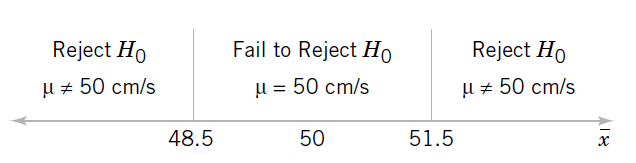

# Prueba de medias con varianza conocida

Cuando no tenemos pautas usamos **estadísticos** y nos preguntamos:

¿Qué tan probable es nuestra observación bajo la **hipótesis nula**?

Procedimiento general para la prueba de hipótesis con un nivel de significancia predefinido $\alpha$

Plantear el problema:

- Desde el contexto del problema, identifique el parámetro de interés: $\mu$ la tasa de quema
- Enuncie la hipótesis nula: $H_0: \mu = 50$.
- Especifique una hipótesis alternativa adecuada: $H_1 \neq 50$.
- Elija un nivel de significancia: $\alpha = 0.05$ (95% de confianza).

# Zona de rechazo

- Definir zona de rechazo:

**Supon** que $H_0$ es **verdadera** y **modelo de probabilidad** es: $X \hookrightarrow N(\mu=50, \sigma^2=4)$

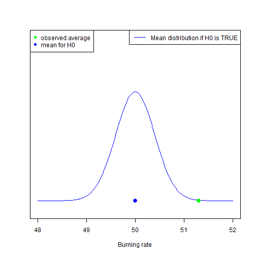

# Zona de rechazo

Define la zona de rechazo:

- Determina un estadístico de prueba adecuada y su distribución para transformar la **hipótesis nula**: $Z_0=\frac{\bar{X}-50}{2/\sqrt{25}}\rightarrow N(\mu=0,\sigma^2=1)$
- Indica la región de rechazo para el estadístico (95% de confianza, o que deja fura de la distribución el 5%): $z_0 < z_{0.975}=-1.96$ or $z_0 > z_{0.025}=1.96$

# Zona de rechazo

Definir zona de rechazo:

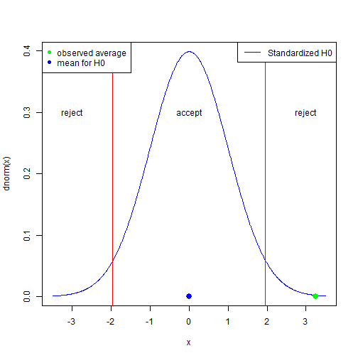

# Prueba de medias con varianza conocida

Ahora usa **datos** para sacar conclusiones:

- Calcula las cantidades de muestra necesarias, sustitúyelas en la ecuación del estadístico de prueba y calcula el valor **observado**. $z=\frac{51.3-50}{2/\sqrt{25}}=3.25$
- **Decide** si se debe rechazar $H_0$ o no e informa el resultado de acuerdo al contexto del problema: $z> 1.96$ y $H_0$ se rechaza.

De acuerdo con el valor del estimador, el experimentador **no puede aceptar** con una confianza del 95% que la velocidad de combustión de su prototipo es la esperada $50 cm/s$

- $H_0$ aún podría ser cierto, pero entonces la observación sería **muy rara**.

# Prueba de medias con varianza conocida: intervalos de confianza

Veamos el problema desde el punto de vista de la estimación.

El intervalo de confianza del 95% para $\bar{x}$ viene dado por

$CI=(\bar{x}-z_{\alpha/2}\sigma/\sqrt{n},\bar{x}+z_{\alpha/2}\sigma/\sqrt{n})$

$=(50.516,52.084)$

que claramente no contiene $50$. El intervalo da una idea del rango y la distancia de los resulados con respecto a la hipótesis nula.

# Prueba de medias con varianza conocida: intervalos de confianza

El intervalo de confianza no **captura** la hipótesis.

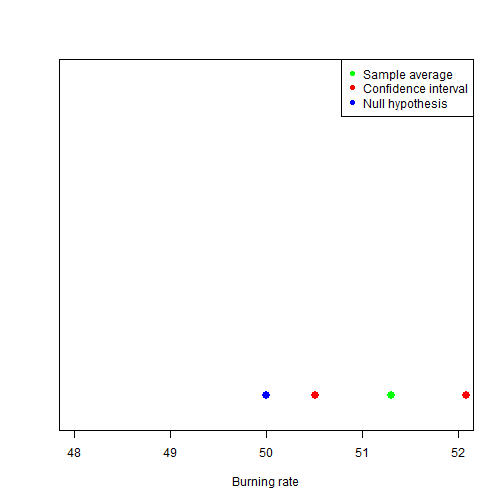

# Prueba de medias con varianza conocida: intervalos de confianza

Si $H_0$ es verdadero, entonces esta es una observación poco común del IC que ocurre solo el 5% de las veces.

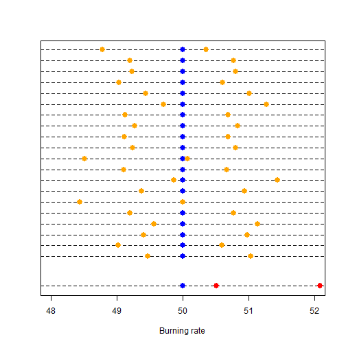

# Prueba de medias con varianza conocida: intervalos de confianza

Recuerda nuestra discusión sobre los intervalos de confianza: A partir de la distribución del estimador de $\Theta$, definimos un **límite de confianza** $\alpha$ tal que

$P(L < \theta < U ) = 1-\alpha$

Dado que $1- \alpha$% de las veces capturamos la media, si el IC no contiene la hipótesis nula, entonces

- el experimentador tuvo muy mala suerte ($\alpha$; 5%)
- la media real fue realmente capturada por el IC y **no es** la hipótesis nula ($1- \alpha$; 95%)

Si tuvieras que apostar por aguna de estas dos situaciones, ¿dónde pondrías tu dinero?

De acuerdo con el intervalo de confianza, el experimentador **no puede aceptar** con una confianza del 95% que la velocidad de combustión de su prototipo es la esperada $50 cm/s$.

# Prueba de hipótesis

Dada una hipótesis $H_0: \theta=\theta_0$ y unos datos $x_1,...x_n$, calculamos la estimación de $\theta$ mediante un estimador $\Theta$ (es decir, $\bar{x}$) y su intervalo de confianza $(l, u)$, cuyas expresiones conocemos o podemos derivar usando, por ejemplo, máxima verosimilitud, asumiendo una distribución para $\Theta$.

Rechazamos la hipótesis nula con la probabilidad de un falso positivo $\alpha$ cuando

- el estimador cae en la región crítica de $H_0$ que da una probabilidad de $\alpha$
- el intervalo de confianza $(1- \alpha) 100 \%$ no contiene $\theta_0$

De lo contrario, no podemos rechazar la hipótesis nula. Suponemos que los datos podrían haber sido producidos por la hipótesis nula.

# Prueba de medias con varianza conocida: P valor

Podemos probar si una hipótesis nula puede rechazarse o no.

- Sin embargo, si la estimación cae fuera de la región de aceptación, es útil saber qué tan lejos está de los límites.
- Las Estimaciónes que están lejos de los límites, bien dentro de la región de rechazo son más creíbles.
- ¿Cómo reportamos qué tan significativa es nuestra estimación al rechazar la hipótesis nula, o lejos de los límites de la región de aceptación?

# Prueba de medias con varianza conocida: P valor

Rechazando la hipótesis con un P valor:

Cuando el experimentador probó la hipótesis nula transformándola en una distribución estándar, transformamos el promedio **observado** en:

$z=\frac{51.3-50}{2/\sqrt{25}}=3.25$

De hecho, el valor de $z = 3.25$ da una fuerte evidencia del rechazo de $H_0$.

Si la hipótesis nula es **verdadera** y realizamos otro experimento, la probabilidad de mejorar nuestro resultado es extremadamente baja.

$P=2(1-\Phi(|z|))= 0.0011<<\alpha=0.05$

# Prueba de medias con varianza conocida: P valor

Interpretación:

- Los datos indican que si $H_0$ es verdadero entonces la probabilidad de obtener un resultado que sea al menos el valor dado por los datos es $0.0011$
- Que los datos son un evento tan **raro** por $H_0$ que podemos rechazarlo con confianza.

# Prueba de medias con varianza conocida: P valor

**Definición**

El **P valor** es el nivel más pequeño de significancia que llevaría al rechazo de la hipótesis nula $H_0$ según los datos obtenidos.

Resumiendo: Con unos datos dados $x_1,...x_n$ para una variable aleatoria $X \hookrightarrow f(x; \theta)$

- obtenemos la estimación $\hat {\theta}$
- calculamos la probabilidad de que el estimador $\Theta$ que esté más lejos que el estimado $\hat {\theta}$ cuando $H_0$ sea verdadero: $X \hookrightarrow f(x; \theta_0)$.
- luego rechazamos $H_0$ si $P <\alpha$

$P$ nos da qué tan lejos estamos de $\theta_0$.

La hipótesis nula se puede probar con la zona de rechazo, CI o valores P. Los tres son equivalentes.

# Hipótesis de una o dos colas

**Prueba de dos colas**: Cuando consideramos las dos colas de la distribución, o cuando se espera que la hipótesis nula tome un valor $\mu_0$.

- $H_0$ cuando $\mu=\mu_0$
- $H_1$ cuando $\mu \neq \mu_0$

La alternativa puede ser mayor o menor.

Nuestro ejemplo de velocidad de combustión es una prueba de dos colas

- $H_0: \mu= 50cm/s$ (hipótesis nula)
- $H_1: \mu\neq 50cm/s$ (hipótesis alternativa)

# Hipótesis de dos colas

Es importante que el experimentador queme el propulsor a una velocidad adecuada. Si la velocidad es demasiado alta o demasiado baja, la propulsión no funcionará.

$$P=2(1-F(|z|))$$

si $Z \hookrightarrow N(0,1)$ entonces $F=\Phi$

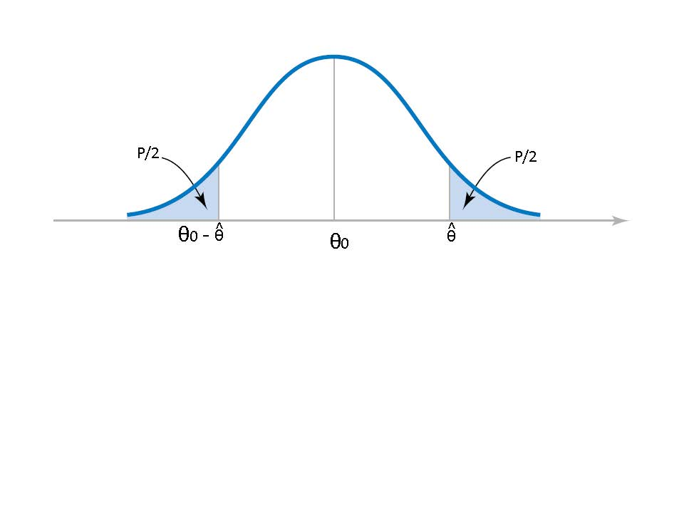

# Hipótesis de cola superior

Prueba de **cola superior**:

Cuando consideramos la cola superior de la distribución, o cuando se espera que la estimación $\hat{\theta}$ tome solo **valores mayores** que $\theta_0$

La eficacia de algunos tratamientos farmacológicos es del 70%. Si creemos que hemos mejorado la eficacia del tratamiento,

- $H_0: \mu=\mu_0= 0.70$ (hipótesis nula, simple)
- $H_1: \mu > \mu_0$ (hipótesis alternativa)

# Hipótesis de cola superior

$$P=(1-F(z))$$

si $Z \hookrightarrow N(0,1)$ entonces $F=\Phi$

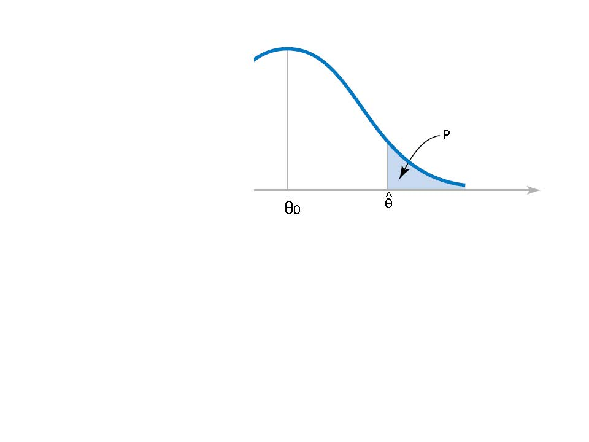

# Hipótesis de cola inferior

La eficiencia media de combustión de un automóvil es de $6Lt / 100Km$. Si pensamos que hemos mejorado la eficiencia de su combustión entonces

- $H_0:\mu=\mu_0=6Lt/100Km$
- $H_1:\mu < \mu_0$

# Hipótesis de cola inferior

cuando
$$P=F(z)$$

si $Z \hookrightarrow N(0,1)$ entonces $F = \Phi$

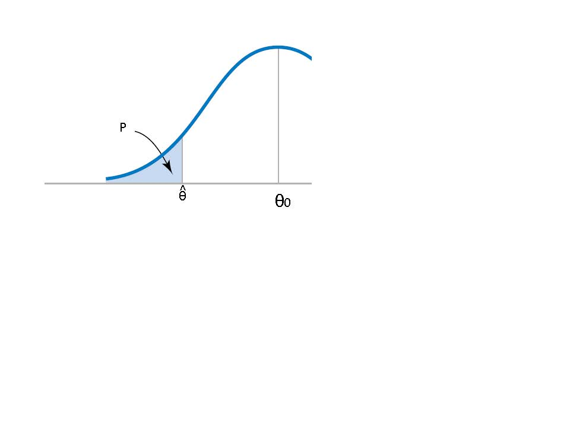

# Prueba de medias con varianza desconocida

- Los sistemas de escape de las tripulaciones aéreas funcionan con algún propulsor sólido.
- La velocidad de combustión de este propulsor es una característica importante del producto. Las especificaciones requieren que la tasa de combustión media debe ser de $50 cm/s$.
- **Sabemos** que la desviación estándar de la combustión $\sigma = 2cm/s$. **¿Como lo sabemos?**
- El experimentador diseña un nuevo propulsor y produce una muestra de $n = 25$ con una tasa de combustión promedio de la muestra de $\bar{x} = 51.3 cm / s$
- ¿Puede el experimentador garantizar la combustión segura no demasiado **baja** ni demasiado **alta** del nuevo producto con un 95% de confianza?

# Prueba de medias con varianza desconocida

Los argumentos anteriores se extienden fácilmente cuando no conocemos la varianza.

En general, si consideramos el caso en el que

- muestra $X_1, ... X_n$ de una muestra de población $X\rightarrow N(\mu, \sigma)$
- $H_0: \mu=\mu_0$ es la hipótesis nula
- $H_1$ es la hipótesis alternativa

y estimamos $\sigma ^ 2$ con $S ^ 2$,

¿Cuál debería ser el estadístico y su distribución en este caso?

# Prueba de medias con varianza desconocida

Recuerda que si estimamos la varianza $\sigma^ 2_X$ con la varianza muestral $S^2$ y $X\rightarrow N(\mu_X, \sigma^2_X)$, entonces el estadístico estandarizado

$T=\frac{\bar{X}-\mu}{\frac{S}{\sqrt{n}}}$ sigue una distribución T con $n-1$ grados de libertad.

Luego, cuando realizamos una prueba de **dos colas** para $H_0$, deberíamos rechazar $H_0$ a nivel $\alpha$ si:

$t<-t_{\alpha/2,n-1}$ o $t_{\alpha/2,n-1}\lt t$

- $CI=(\bar{x}-t_{\alpha/2,n-1}s/\sqrt{n},\bar{x}+t_{\alpha/2,n-1}s/\sqrt{n})$ no contiene $\mu_0$
- O, $P=2(1-f_{t(n-1)}(|t|))<\alpha$

que son todos equivalentes

# Prueba de medias con varianza desconocida

- Una cinta está diseñada para romperse a 185 libras.
- Se seleccionan al azar cinco muestras y se prueban con valores de rotura;

171.6, 191.8, 178.3, 184.9, 189.1.

- prueba la hipótesis nula $\mu = 185$ contra la alternativa $\mu <185$ al nivel significancia $0.05$.

# Prueba de medias con varianza desconocida

Por lo tanto tenemos el

- $H_0:\mu=185$
- $H_1:\mu < 185$
- $\alpha=0.05$
- datos: 171.6, 191.8, 178.3, 184.9 and 189.1.

¿Cuál es la región crítica?

# Prueba de medias con varianza desconocida

Estamos buscando el límite superior de la región de la cola inferior de una distribución $t(n-1)$ que tiene una probabilidad $\alpha = 0.05$

Eso es:

$P(T \leq t_{0.95,n-1=4})=0.05$  
$F(t_{0.95,n-1=4})=0.05$  
$t_{0.95,4}=F^{-1}_{t,4}(0.05)=$`qt(0.05,4)`$=-2.13$

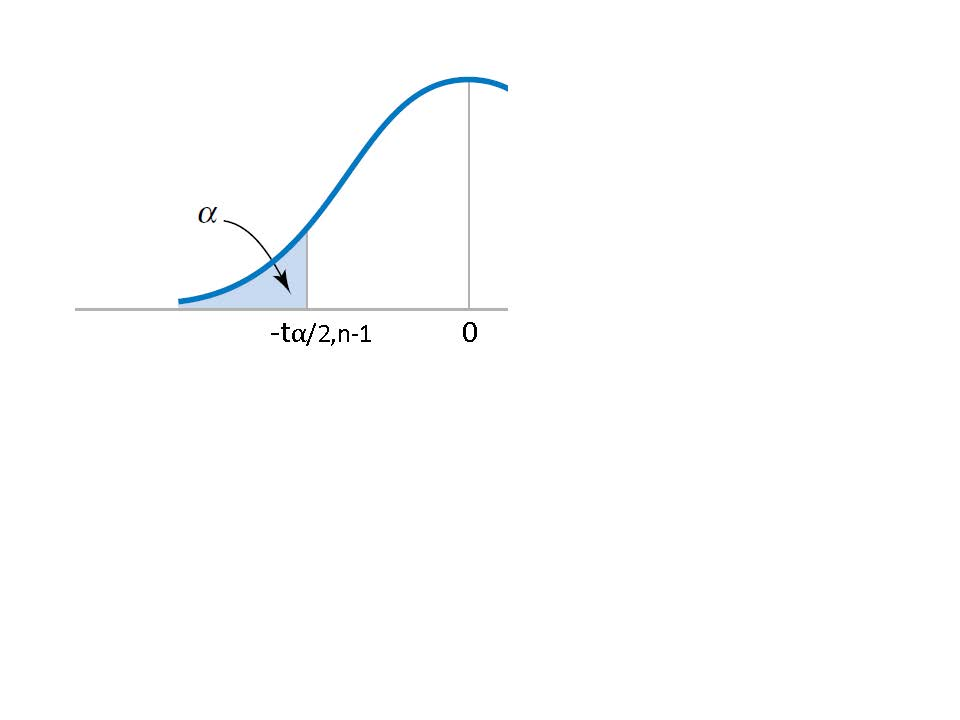

busquemos en una tabla …

# Prueba de medias con varianza desconocida

¡Recuerda que la distribución es simétrica!

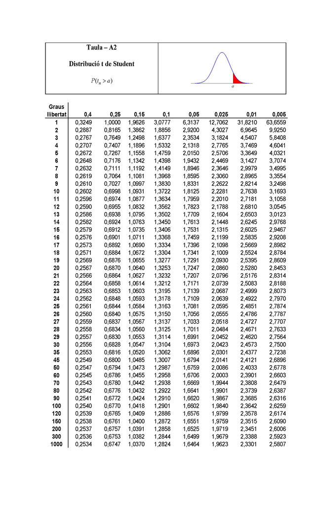

# Prueba de medias con varianza desconocida

Deberías encontrar $t_{0.05,4}=2.132$ y $t_{0.95,4}=-2.132$

Entonces tenemos:

- $H_0:\mu=185$
- $H_1:\mu < 185$
- $\alpha=0.05$
- data: 171.6, 191.8, 178.3, 184.9 and 189.1.
- la región crítica es: $t <-2.132$

¿Cuál es el valor del estadístico t?

# Prueba de medias con varianza desconocida

Bajo la hipótesis nula $t$ es la variable estandarizada $t=\frac{\bar{x}-\mu_0}{s/\sqrt{5}}$

a partir de los datos: 171.6, 191.8, 178.3, 184.9 y 189.1. obtenemos $\bar{x}=183.1$ y $s=8.2$

$$t=\frac{183.1-185}{8.2/\sqrt{5}}=-0.49$$

que no es menor que el valor crítico $-2.132$ y por lo tanto concluimos que los datos son consistentes con $H_0$ y no podemos rechazarlos.

# Prueba de varianzas

En muchos casos, se realizan experimentos para probar valores específicos de la dispersión de datos.

Tal como

- para cumplir con estrictos estándares de diseño donde las medidas deben estar entre ciertos valores
- cuando se toman medidas relativas, como la reacción de un tratamiento en un individuo (administración de insulina en los niveles de azúcar de un individuo)

# Prueba de varianzas

Para una muestra aleatoria $X_1, ... X_n$ con una distribución de población normal ($X_i \rightarrow N(\mu, \sigma^2)$) los estadísticos definidas por

$$X=\frac{(n-1)S^2}{\sigma^2}$$

Tiene una distribución $\chi^2$ (chi-cuadrado) con n-1 grados de libertad dados por

$$f(x)=C_n x^{\frac{n-3}{2}} e^{-\frac{x}{2}}$$

# Prueba de varianzas

Supongamos que queremos probar si la varianza de la distribución de la población es igual a un valor dado $ sigma_0 $

- $H_0:\sigma=\sigma_0$

Hipótesis alternativa

- dos colas:$H_1:\sigma \neq \sigma_0$
- de cola superior:$H_1:\sigma > \sigma_0$
- de cola inferior: $H_1:\sigma < \sigma_0$

# Prueba de varianzas

Sabemos que

- $S ^ 2$ es una estimación imparcial de $\sigma ^ 2$: $E (S ^ 2) = \sigma ^ 2$

Luego, bajo la hipótesis nula, $H_0: \sigma = \sigma_0$ el estadístico
$$X=\frac{(n-1)S^2}{\sigma_0^2} \rightarrow \chi^2(n-1)$$

# Prueba de varianzas

Para una prueba de dos colas, $H_0$ se rechaza si los datos caen

$\chi_0^2< \chi^2_{1-\alpha/2,n-1}$ or $\chi_0^2>\chi^2_{\alpha/2,n-1}$

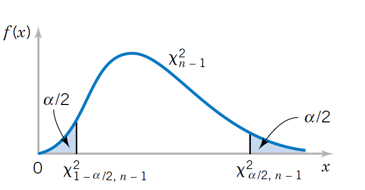

# Prueba de varianzas

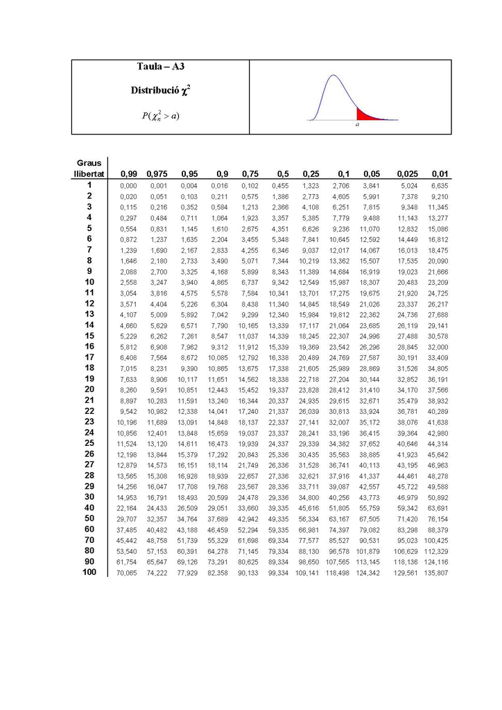

# Prueba de varianzas

- La producción de un chip semiconductor está regulada por un proceso que requiere que el grosor de una capa en particular no sea mayor que $\sigma_0 = 0.6mm$.
- Mantener el control del proceso cada cierto tiempo una muestra de 20 ejemplares.
- Si en una ocasión el error estándar de la muestra $s = 0,84$, ¿el proceso está fuera de control con una confianza de 0,01 y debería detenerse?

# Prueba de varianzas

- $H_0:\sigma=\sigma_0=0.6$
- de cola superior:$H_1:\sigma > \sigma_0$
- Estadístico: $Y=\frac{(n-1)S^2}{\sigma_0^2} \rightarrow \chi^2(n-1)$
- $\alpha=0.01$
- región crítica: $Y>\chi^2_{0.01,19}$

¿Cuál es el valor crítico?

# Prueba de varianzas

$P(Y > \chi^2_{0.01,19})=0.01$

$1-P(Y \leq \chi^2_{0.01,19})=0.01$

$P(Y \leq \chi^2_{0.01,19})=0.99$

$F(\chi^2_{0.01,19})=0.99$

$\chi^2_{0.01,19}=F^{-1}(0.99)=$`qchisq(0.99,19)`$= 36.19$

busquemos en una tabla …

# Prueba de varianzas

$P(Y > \chi^2_{0.01,19})=0.01$

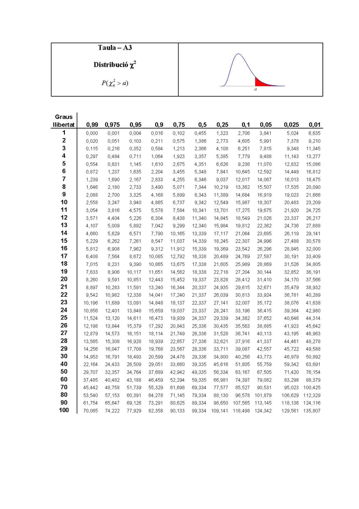

# Prueba de varianzas

El proceso estará fuera de control si

$$\frac{(n-1)S^2}{\sigma_0^2}$$

con $n = 20$ y $\sigma = 0.60$ es mayor que

$$\chi^2_{0.01,19}=36.191$$

$$\frac{19 (0.84)^2}{0.60^2}=37.24$$

Dado que el valor de nuestro experimento es mayor que el valor crítico, entonces: ¡Sí! el proceso está fuera de control.

# Errores en la prueba de hipótesis

Cuando inferimos un parámetro con una estadística y luego aplicamos un criterio para decidir sobre una hipótesis, tenemos cuatro posibilidades

- $H_0$ realidad desconocida: **verdadero**, **falso**
- $H_0$ pruebas observadas: **aceptar**, **rechazar**

[output not shown]

Por lo general, nuestro objetivo es rechazar $H_0$ (fiscal)

# Errores en la prueba de hipótesis

Te haces una prueba de PCR $H_0$ no estás infectado

- $H_0$ realidad desconocida: **verdadero**, **falso**
- $H_0$ pruebas observadas: **aceptar** (negativo), **rechazar** (positivo)

| $H_0$ | no infectado: verdadero | no infectado: falso (infected: true) |
| --- | --- | --- |
| **negative** (aceptar) | verdadero negativo: $P(aceptar\|H_0:verdadero)$ | falso negativo:$P(acceptar\|H_0:falso)$ |
| **positive** (rechazar) | falso positivo: $P(rechazar\|H_0:verdadero)$ | verdadero positivo: $P(rechazar\|H_0:falso)$ |
| **sum** | 1 | 1 |

# Errores en la prueba de hipótesis

Los errores también se conocen como

- Error tipo I: falso positivo $\alpha=P (rechazar | H_0: verdadero)$
- Error de tipo II: falso negativo $\beta=P (aceptar | H_0: falso)$

| $H_0$ | no infectado: verdadero | no infectado: falso (infected: true) |
| --- | --- | --- |
| **negative** (aceptar) | verdadero negativo: $P(aceptar\|H_0:verdadero)$ | Error de tipo II:$P(acceptar\|H_0:falso)$ |
| **positive** (rechazar) | Error tipo I: $P(rechazar\|H_0:verdadero)$ | verdadero positivo: $P(rechazar\|H_0:falso)$ |
| **sum** | 1 | 1 |

# Estadísticas bayesianas

¿Qué pasa si aplicamos el teorema de Bayes a la tabla anterior?

$$P(H_0|data)=\frac{P(data|H_0)P(H_0)}{P(data)}$$

Subvertimos el significado de un evento y lo aplicamos a una hipótesis

¿Podemos asignar una probabilidad a una hipótesis?

Interpretación bayesiana de la probabilidad

- La probabilidad es nuestro estado de creencia sobre la veracidad de una hipótesis dados los datos.

Pero esto abre un mundo completamente nuevo sobre los estadísticos y el método científico y nuestra comprensión de los experimentos aleatorios.

# De el estadístico a la ciencia de datos

- Integración de datos y modelos
- Predicción e inferencia (prueba de hipótesis)

*Datos*: Mercancía más valiosa. Los procesos generan cantidades masivas de datos.

*Modelos*: inferidos por ordenadores (AI). Cantidades masivas de modelos.